# Twistcode’s Forecast on

12th Sarawak State Election,2021

Twistcode AI Team

2021-12-17

[figure not shown]

# 1 Introduction

Forecasting political elections has attracted a lot of attention especially here in Malaysia after 14th General Election (GE), 2018. The big question is how far can we forecasting election outcome using programmable model where the event is known to be complex.

Common poll surveys and economic growth at the national level are usually use as the predictive factors in forecasting model. Here in this report, we use social media platform as the primary parameter and can be consider as *atas pagar* (indecisive) voters as they usually contribute in swing vote.

## 1.1 Sentiment Analysis

Sentiment analysis or opinion mining is a field which pre-dominantly revolves around the analysis of opinions.

Outside forecasting political election, sentiment analysis is also use to make stock market prediction, finding customers attitude and trends and also prediction of sales performance.

# 2 Insight 1

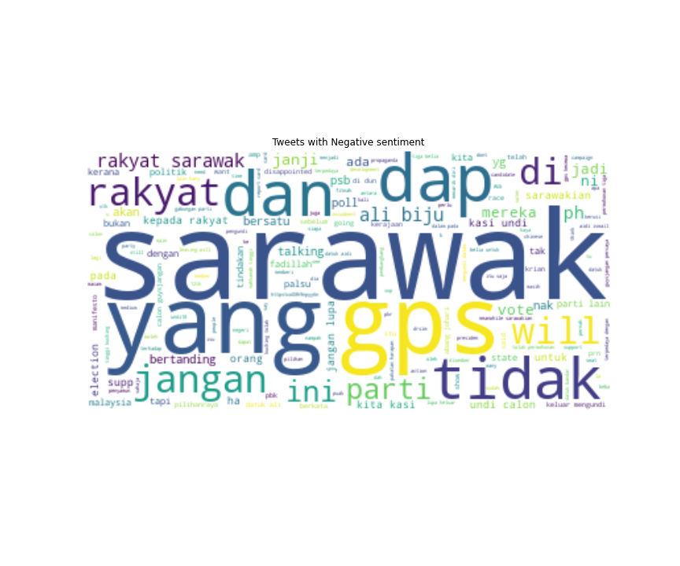

Figure 2: overall negative sentiment

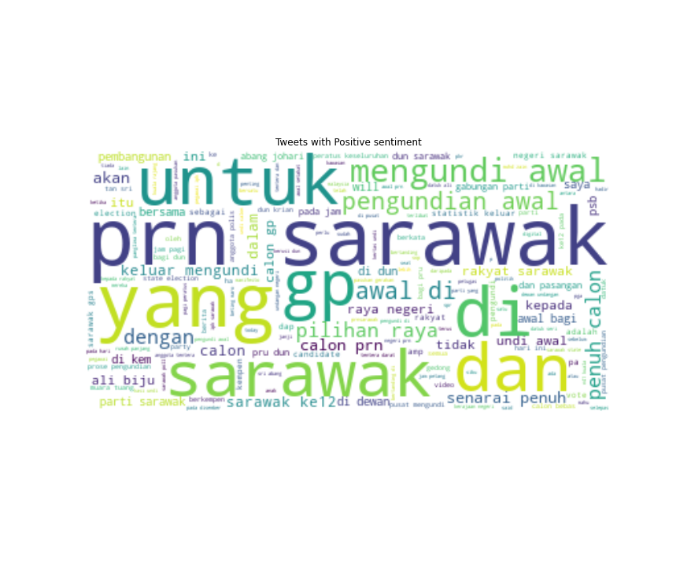

Figure 2: overall positive sentiment

# 3 Insight 2

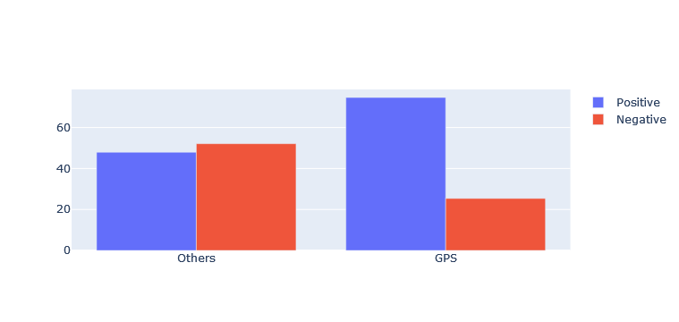

Figure 3: ramalan

# 4 Conclusion

Forecasting an election is complex and can be framed as even more so in an unfamiliar environment with many parameters on the ground. Voters may be more actively partisan than they were in previous elections due to Covid-19 and economics difficulty.

And for this reason, we forecast GPS shall win.

# 5 Note

We acknowledge that data is scarce for this forecast using AI/ML. But this is just the beginning.